# Lab 6: Data Visualization with ggplot2

You can download the .html file for this lab from the class Brightspace site.

# Introduction to Data Visualization

Here is an example of data visualization (with R package *ggplot2*):

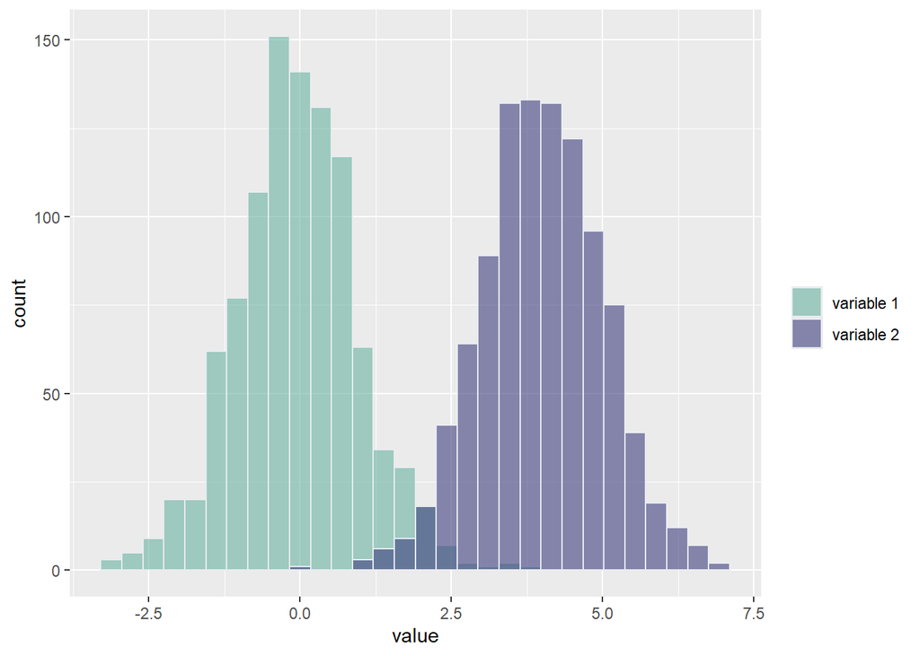

```r
# Generate example data with different distributions
data1 <- data.frame(
  type = c( rep("variable 1", 1000), rep("variable 2", 1000) ),
  value = c( rnorm(1000), rnorm(1000, mean=4) )
)

# Visualize it
data1 %>%
  ggplot( aes(x=value, fill=type)) +
    geom_histogram( color="#e9ecef", alpha=0.6, position = 'identity') +
    scale_fill_manual(values=c("#69b3a2", "#404080")) +
    labs(fill="")
```

Each graph has the following components (refer to the code above):

- `data`: the dataset containing the variables you want to visualize
- `aes`: the aesthetic attributes you want to apply to the geometric object (including which variables should be mapped onto the x & y axis, or determine the color, shape, and size of the geometric objects)
- `geom`: the type of geometric object you want to graph. The geometric object defines how data will appear visually on the graph—whether as points, lines, bars, etc. `geom` can also have its own aesthetics inside.
- (optional) additional components connected with `+`: add a layer on the graph

**You don’t need to remember the syntax!** Here’s the [ggplot cheat sheet](https://rstudio.github.io/cheatsheets/data-visualization.pdf), or you can access from the drop down menu of Rstudio –> Help –> Cheat Sheets –> Data Visualization with ggplot2

```r
# load the mosaic package for our dataset today
# run install.packages("mosaicData") or install it from the packages tab in RStudio
library(mosaicData)

# load a dataset
data(CPS85, package = "mosaicData")

# Use some quick ways to check the data
head(CPS85)  # check the first few rows
```

```
##   wage educ race sex hispanic south married exper union age   sector
## 1  9.0   10    W   M       NH    NS Married    27   Not  43    const
## 2  5.5   12    W   M       NH    NS Married    20   Not  38    sales
## 3  3.8   12    W   F       NH    NS  Single     4   Not  22    sales
## 4 10.5   12    W   F       NH    NS Married    29   Not  47 clerical
## 5 15.0   12    W   M       NH    NS Married    40 Union  58    const
## 6  9.0   16    W   F       NH    NS Married    27   Not  49 clerical
```

```r
str(CPS85)   # check the structure of the data
```

```
## 'data.frame':    534 obs. of  11 variables:
##  $ wage    : num  9 5.5 3.8 10.5 15 9 9.57 15 11 5 ...
##  $ educ    : int  10 12 12 12 12 16 12 14 8 12 ...
##  $ race    : Factor w/ 2 levels "NW","W": 2 2 2 2 2 2 2 2 2 2 ...
##  $ sex     : Factor w/ 2 levels "F","M": 2 2 1 1 2 1 1 2 2 1 ...
##  $ hispanic: Factor w/ 2 levels "Hisp","NH": 2 2 2 2 2 2 2 2 2 2 ...
##  $ south   : Factor w/ 2 levels "NS","S": 1 1 1 1 1 1 1 1 1 1 ...
##  $ married : Factor w/ 2 levels "Married","Single": 1 1 2 1 1 1 1 2 1 1 ...
##  $ exper   : int  27 20 4 29 40 27 5 22 42 14 ...
##  $ union   : Factor w/ 2 levels "Not","Union": 1 1 1 1 2 1 2 1 1 1 ...
##  $ age     : int  43 38 22 47 58 49 23 42 56 32 ...
##  $ sector  : Factor w/ 8 levels "clerical","const",..: 2 7 7 1 2 1 8 7 4 7 ...
```

```r
# load the tidyverse package,  which includes ggplot2
library(tidyverse)
```

# the data and aes parts

- specify the dataset(s)
- specify aesthetics: maps the variable(s) in the data onto plot parameter(s), for example, y-axis and x-axis
- use the *formula*: `ggplot(data = <data>, mapping = aes(x = <x-axis variable>, y = <y-axis variable>))`

```r
# generate a univariate graph with a categorical variable
ggplot(data = CPS85, mapping = aes(x = sex))
```

[output not shown]

```r
  # and now the sex categories are on our x-axis

# When following the same positioning of arguments, you may omit the "data" and "mapping" arguments.
# That is, R will assume the first argument CPS85 to be the data, and aes(x=sex) as the mapping argument.
ggplot(CPS85, aes(x=sex) )  # this does the same thing as the syntax above
```

## Rename & Reorder Categorical Variables in our data

We need to make sure the categorical variable is a factor, and we can adjust the labels and the order of the categories using the parameter `levels`

```r
# check the class of the variable
class(CPS85$sex)      # or use str()
```

```
## [1] "factor"
```

```r
str(CPS85$sex)     # examine levels of sex again
```

```
##  Factor w/ 2 levels "F","M": 2 2 1 1 2 1 1 2 2 1 ...
```

```r
levels(CPS85$sex)  # another way to examine
```

```
## [1] "F" "M"
```

```r
ggplot(data = CPS85, mapping = aes(x = sex))
```

[output not shown]

```r
# change the ordering of levels in sex
CPS85_clean <- CPS85 %>%
  mutate(sex = factor(sex, levels = c("M", "F")))

str(CPS85_clean$sex)
```

```
##  Factor w/ 2 levels "M","F": 1 1 2 2 1 2 2 1 1 2 ...
```

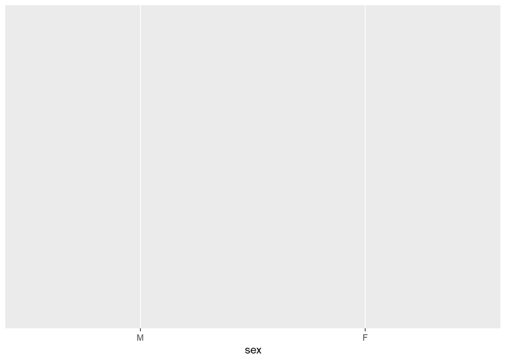

```r
ggplot(data = CPS85_clean, mapping = aes(x = sex))
```

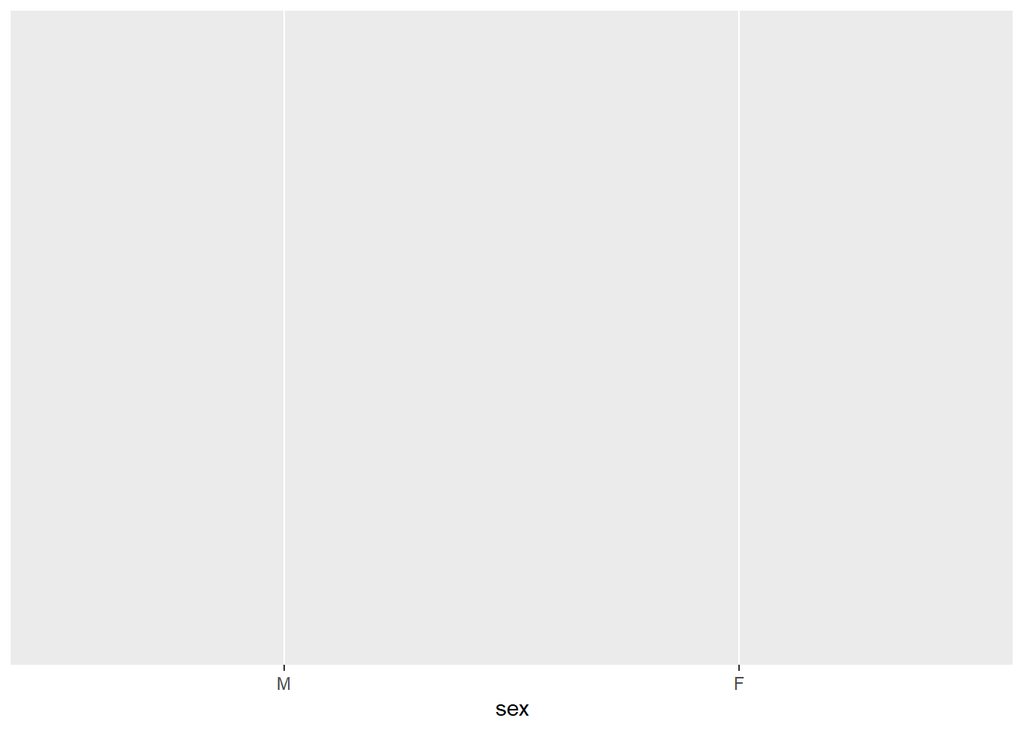

```r
# We can also incorporate the ggplot function inside our pipeline
CPS85 %>%
  mutate(sex = factor(sex, levels = c("M", "F"))) %>%
  # the ggplot function will be applied after "mutate"
  ggplot(mapping = aes(x = sex))
```

```r
  # note that this did not make actual changes to the dataset CPS85
```

# geom_ (geometric objects)

Now with the plot above as the base layer, we use a `+` to add a layer of a geometric object.

- specify the type of graph
- specify grouping variable, when needed
- specify color, shape and size of the geometric objects

## geom_bar for bar charts of one categorical variable

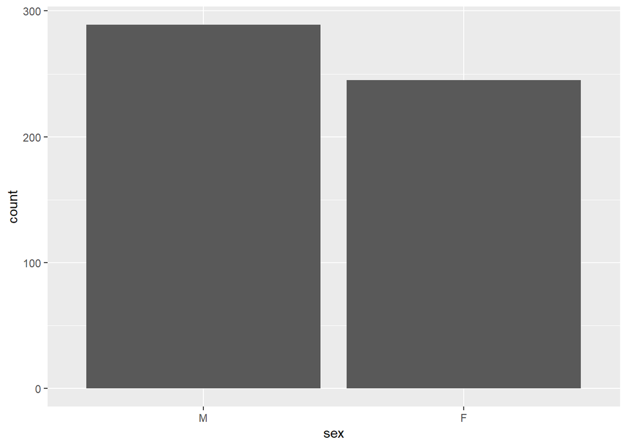

```r
ggplot(data = CPS85_clean, mapping = aes(x = sex)) +
  geom_bar()
```

### Adjust color

We can customize the aesthetics inside the geom objects, for example: we can adjust the filling color by specifying the `fill` parameter, and adjust the shape color by specifying the `color` parameter

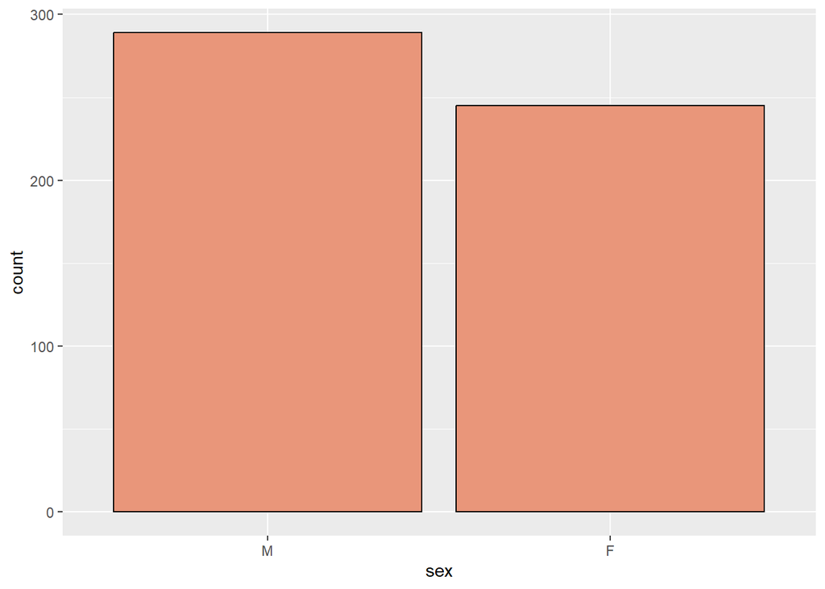

```r
ggplot(data = CPS85_clean, mapping = aes(x = sex)) +
  geom_bar(fill = 'darksalmon', color = 'black')  #fill color: darksalmon, shape color: black
```

```r
#run colors() in your console to quickly see other available colors
```

```r
# [exercise1] Make a bar chart of the variable "married". Pick a color combination you like to fill it:
```

Fill the bars with colors based on the levels of a categorical variable by assigning the categorical variable to `fill`. **Note:** When assigning a variable to `fill`, it has to be inside the same `aes()` as the associated variable.

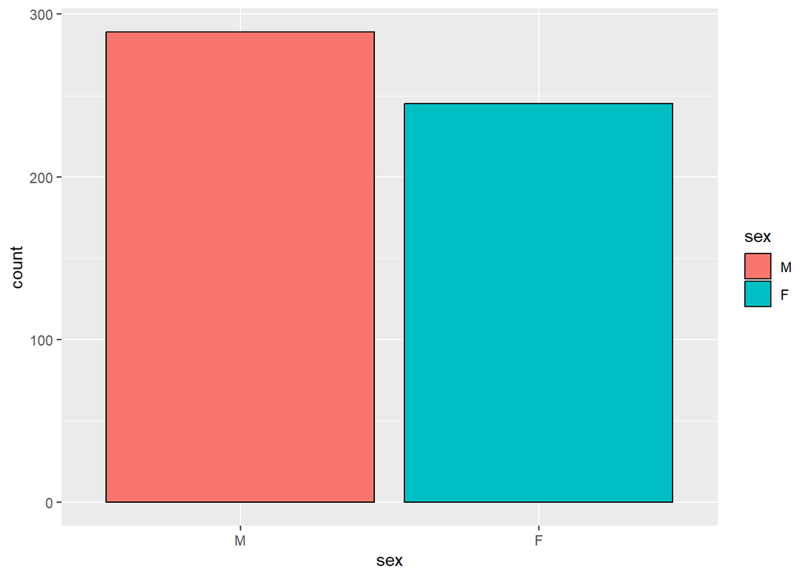

```r
ggplot(data = CPS85_clean, mapping = aes(x = sex, fill = sex)) +
  geom_bar(color = 'black')
```

```r
  #since we are trying to fill the bars mapped from the variable sex, the variable for 'fill' should also be specified in the same aes() argument with x=sex.
```

## geom_histogram for univariate continuous variable

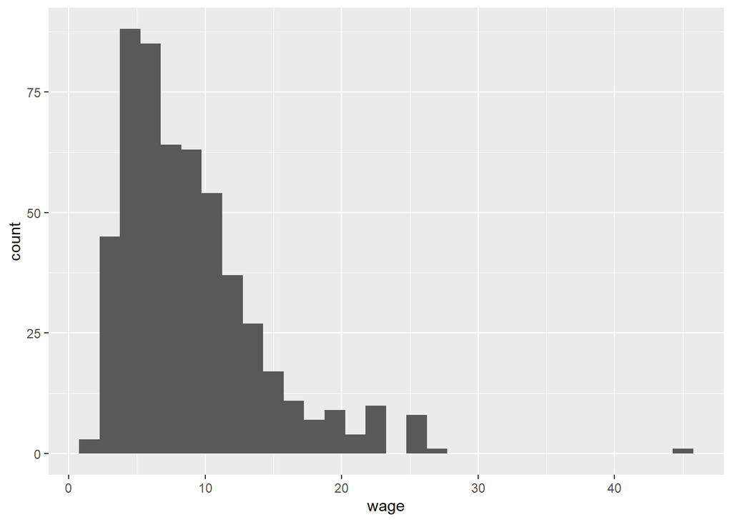

```r
ggplot(CPS85_clean, aes(x = wage)) +
  geom_histogram()
```

### Adjust bin widths

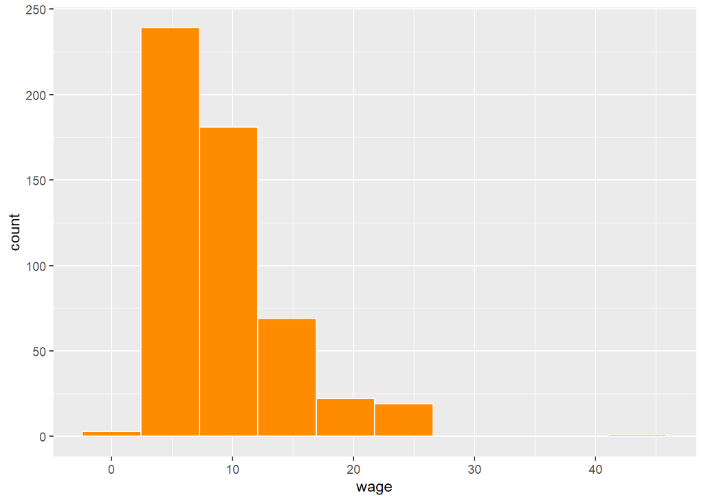

```r
# use a bins of 10
ggplot(CPS85_clean, aes(x = wage)) +
  geom_histogram(fill = "darkorange", color = "white", bins = 10)
```

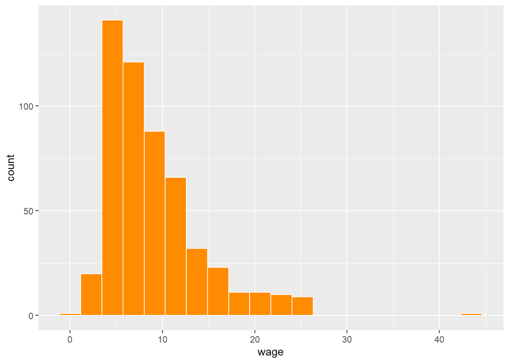

```r
# [exercise2] now try increasing bins to 20, what do you notice?
ggplot(CPS85_clean,aes(x = wage)) +
  geom_histogram(fill = "darkorange", color = "white", bins = 20)
```

## geom_boxplot for univariate continuous variable

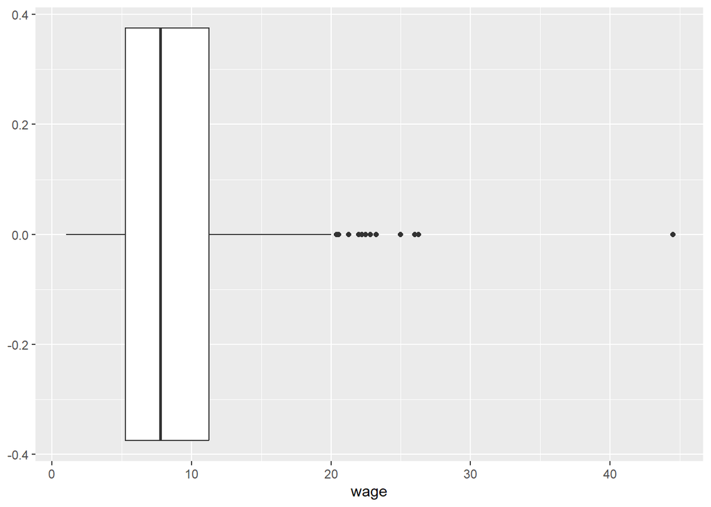

```r
# boxplot of wage
ggplot(CPS85_clean, aes(x = wage)) +
  geom_boxplot()
```

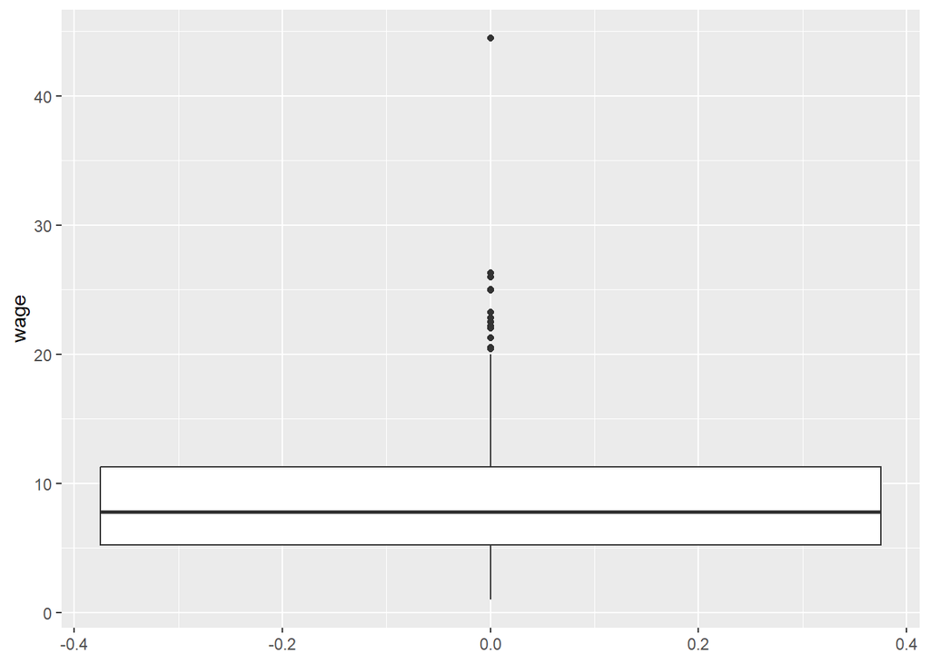

```r
ggplot(CPS85_clean, aes(y = wage)) +
  geom_boxplot()
```

```r
  # What's different when we map wage onto y instead of onto x?
```

## geom_bar for bivariate bar charts: Categorical vs. Categorical

`Fill` the bars with different colors according to sex, and in the geom_bar() function, specify the types of barplot by `position`.

```r
# Using the bivariate correlation between sector and sex as example:
table(CPS85_clean$sector, CPS85_clean$sex, useNA = "ifany")
```

```
##
##             M  F
##   clerical 21 76
##   const    20  0
##   manag    34 21
##   manuf    44 24
##   other    62  6
##   prof     53 52
##   sales    21 17
##   service  34 49
```

### Stacked bar chart

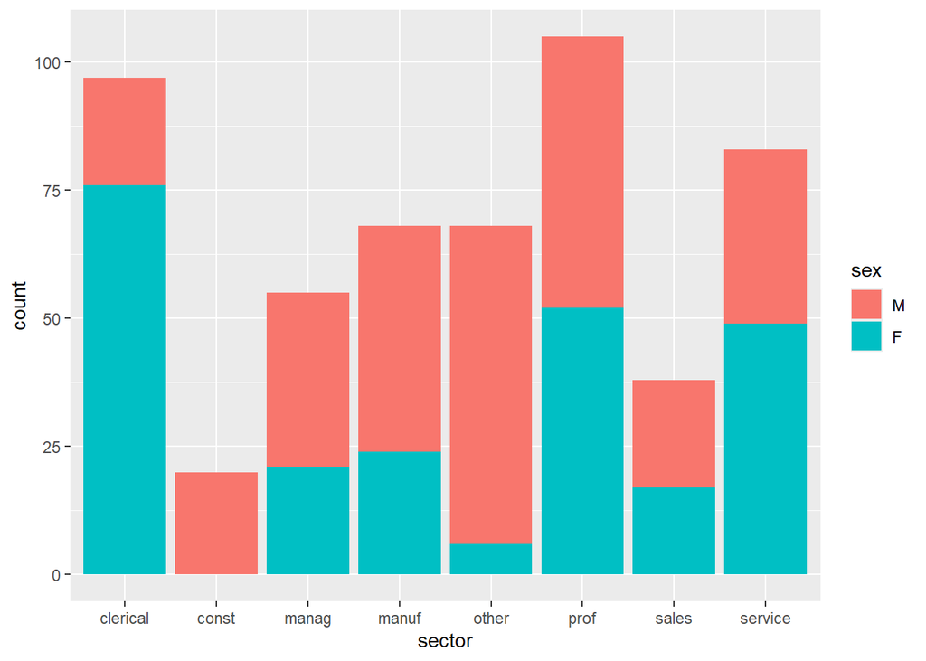

```r
ggplot(CPS85_clean, aes(x = sector,fill = sex)) +
  geom_bar(position = "stack")  # "stack" is the default option of position, so if we do not specify any position, we will get the same type of plot
```

### Grouped bar chart, segmented bar chart

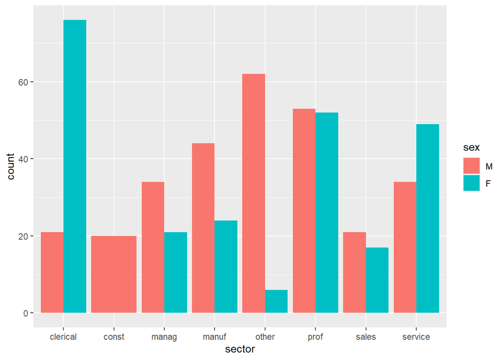

```r
# [exercise3] Change position to "dodge" to create a grouped bar chart:
ggplot(CPS85_clean, aes(x = sector,fill = sex)) +
  geom_bar(position = "dodge")
```

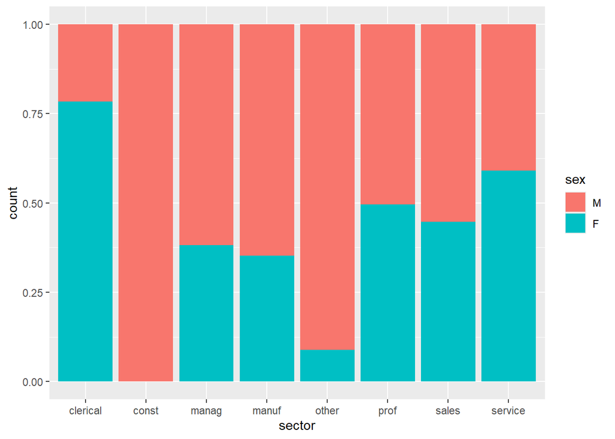

```r
# [exercise4] Change position to "fill" to create a segmented bar chart:
ggplot(CPS85_clean, aes(x = sector,fill = sex)) +
  geom_bar(position = "fill")
```

## geom_boxplot for boxplot of categorical vs. continuous

specify the continuous variable with `y=`

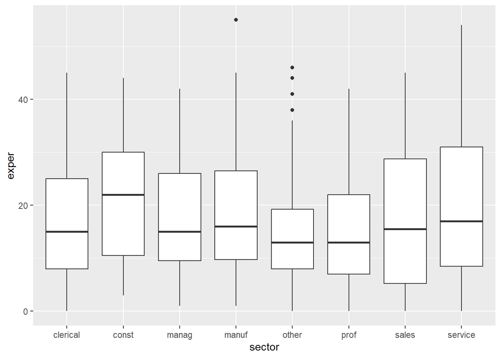

```r
ggplot(CPS85_clean, aes(x = sector, y = exper)) +
  geom_boxplot()
```

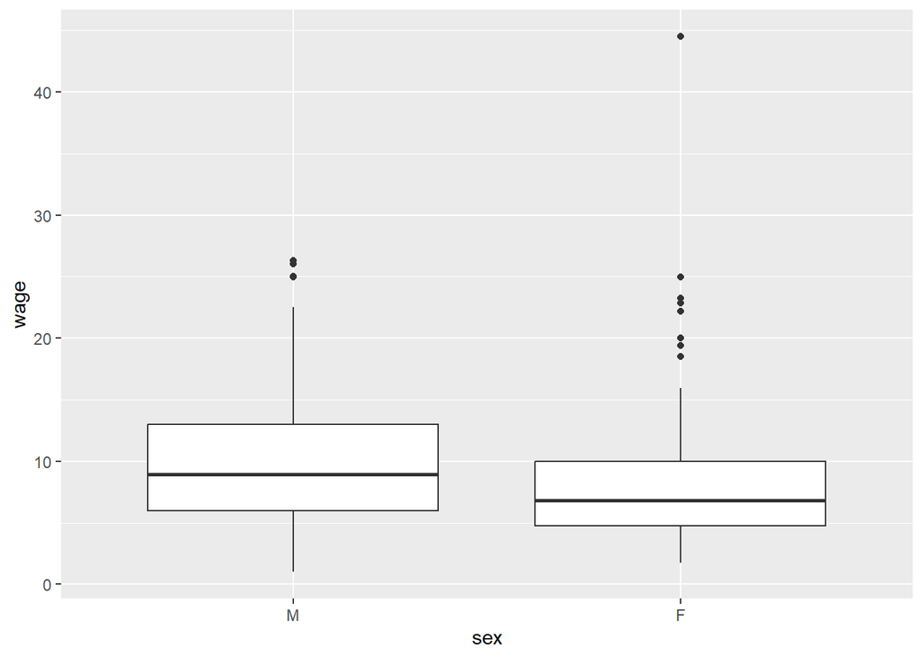

```r
# [exercise5] How would we plot the distribution of wage vs. sex?
ggplot(CPS85_clean, aes(x = sex, y = wage)) +
  geom_boxplot()
```

## geom_point for scatterplot of two continuous variables

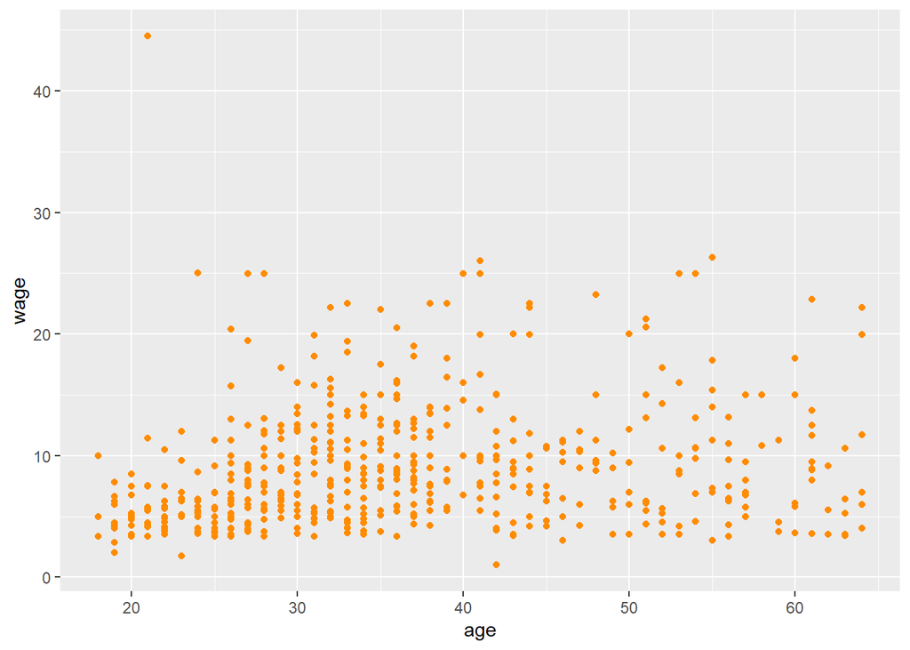

```r
# scatterplot of wage vs. age
ggplot(CPS85_clean, aes(x = age,y = wage)) +
  geom_point(color= "darkorange")
```

# Grouping

## Add a grouping variable with color

Specify the grouping variable with color by adding `color` to `aes`

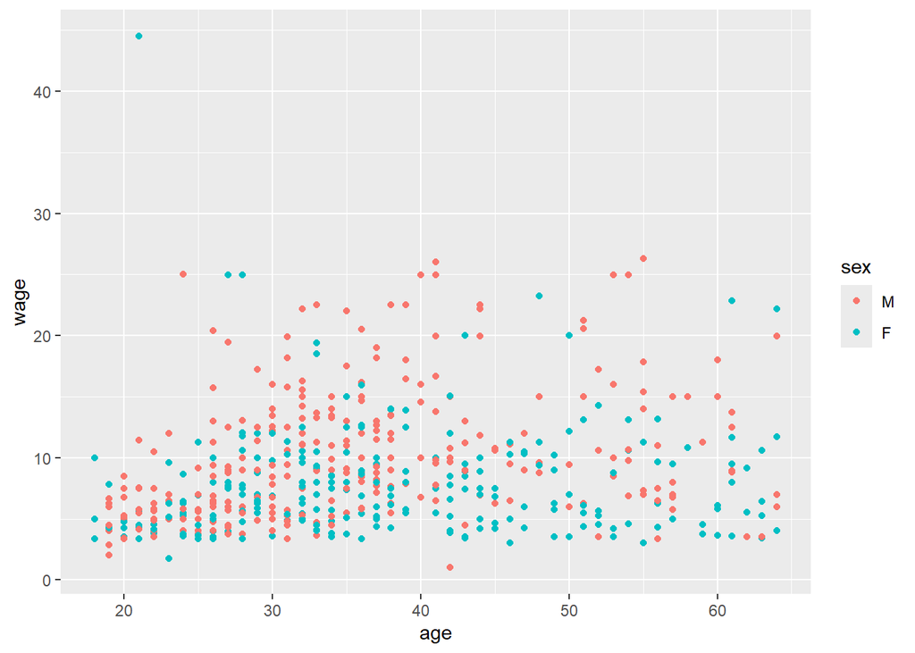

```r
# scatterplot of wage vs. age, grouped by sex
ggplot(CPS85_clean, aes(x = age,y = wage, color=sex))+
  geom_point()
```

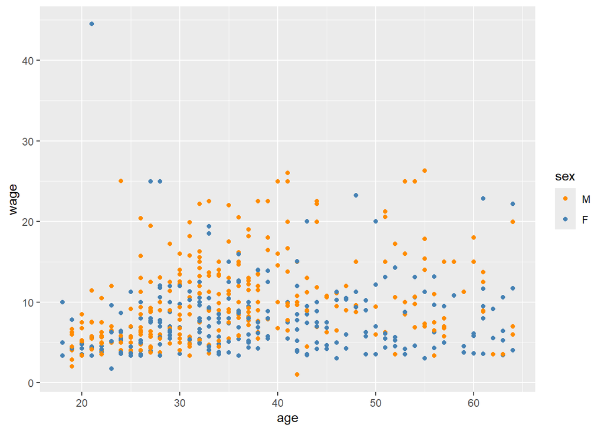

```r
# What if I want to assign my own colors?
ggplot(CPS85_clean, aes(x = age,y = wage, color=sex))+
  geom_point() +
  scale_color_manual(values = c("darkorange", "steelblue"))
```

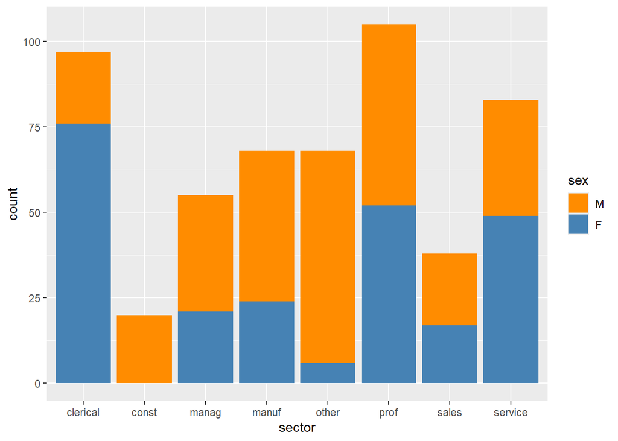

```r
# [exercise6] For the stacked bar chart of sector we did earlier, assign your own colors to sex
# (hint: use scale_fill_manual instead of scale_color_manual since fill=sex in geom_bar)
ggplot(CPS85_clean, aes(x = sector,fill = sex)) +
  geom_bar(position = "stack")  +
  scale_fill_manual(values = c("darkorange", "steelblue"))
```

## Add a grouping variable with facets

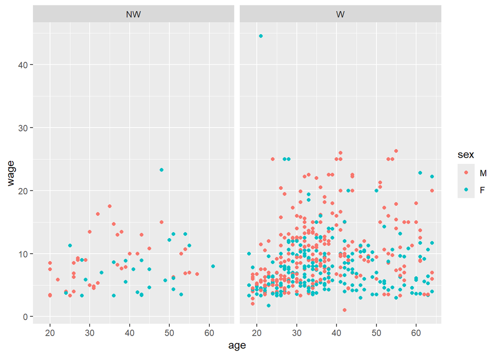

```r
# scatter plot of wave vs. age, grouped by sex, stratified by race
ggplot(CPS85_clean, aes(x = age,y = wage, color=sex))+
  geom_point() +
  facet_wrap(~race)
```

# Scales and legends

Now we have the basic canvas (from data and aes) and the geom component on it, we can add optional components with `+` to adjust the scales, labels, and themes of the plot. This makes our plots more informative and professional.

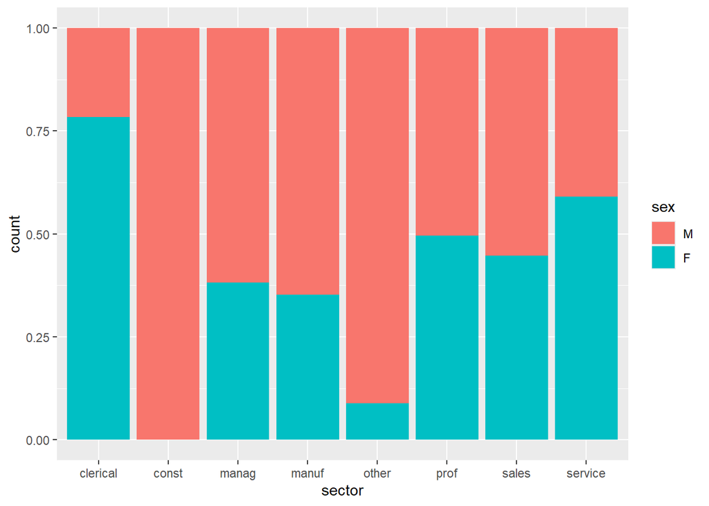

```r
# For example, for this bar chart:
ggplot(CPS85_clean, aes(x = sector,fill = sex)) +
  geom_bar(position = "fill")
```

[figure not shown]

```r
# We can add labs() and scale_fill_manual()
ggplot(CPS85_clean, aes(x = sector,fill = sex)) +
  geom_bar(position = "fill") +
  labs(y = "Proportion", x= "Sector",    #add labels to y-axis and x-axis
       title = "Proportions of sex in each sector") +  #add a title
  scale_fill_manual(
    values = c("darkorange", "steelblue"),  # customize colors
    labels = c("Female", "Male")            # Relabel the legend
  )
```

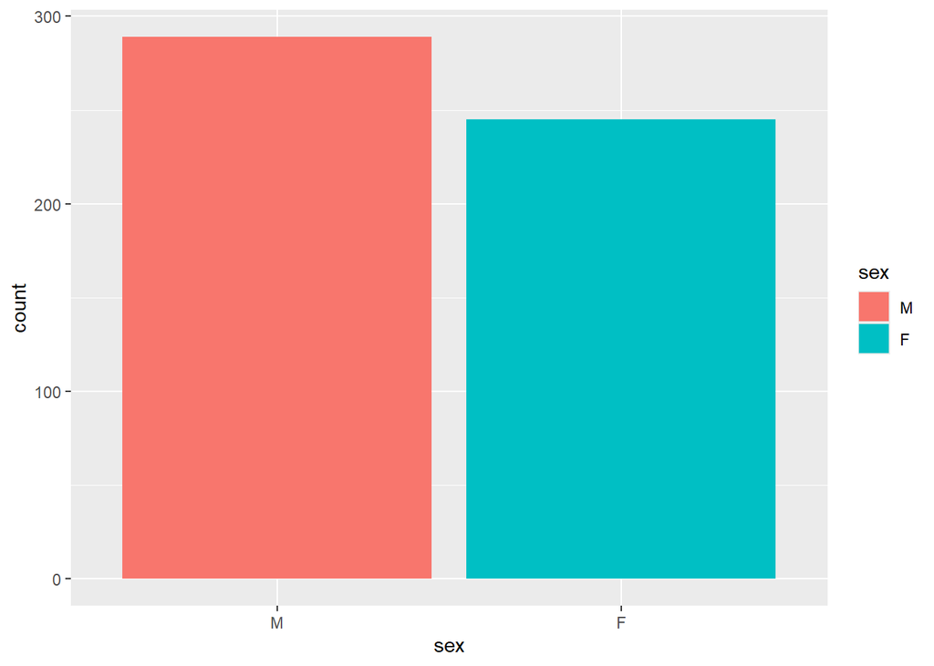

```r
# Similarly, for this bar chart of sex where F and M are not labeled:
ggplot(data = CPS85_clean, mapping = aes(x = sex, fill=sex)) +
  geom_bar()
```

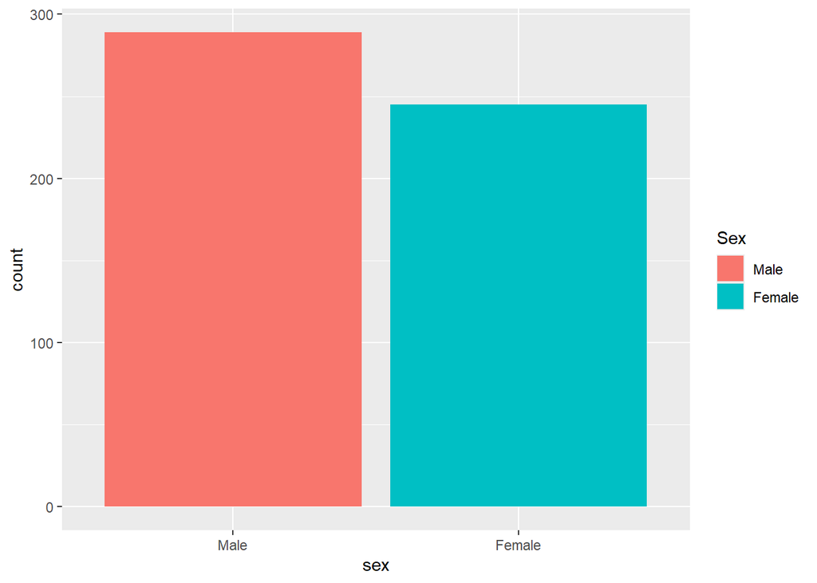

```r
# We can add labels on the x-axis and on the legend
ggplot(data = CPS85_clean, mapping = aes(x = sex, fill=sex)) +
  geom_bar() +
  scale_x_discrete(limits = c("M", "F"),  # need to match the original levels of the factor
                   labels = c("Male", "Female")) + # need to match the order of the limits
  scale_fill_discrete(name = "Sex", labels = c("Male", "Female"))
```

## Continuous Variables

### Adjust the label intervals

specify the min, max and interval with `scale_x_continuous(breaks = seq())`

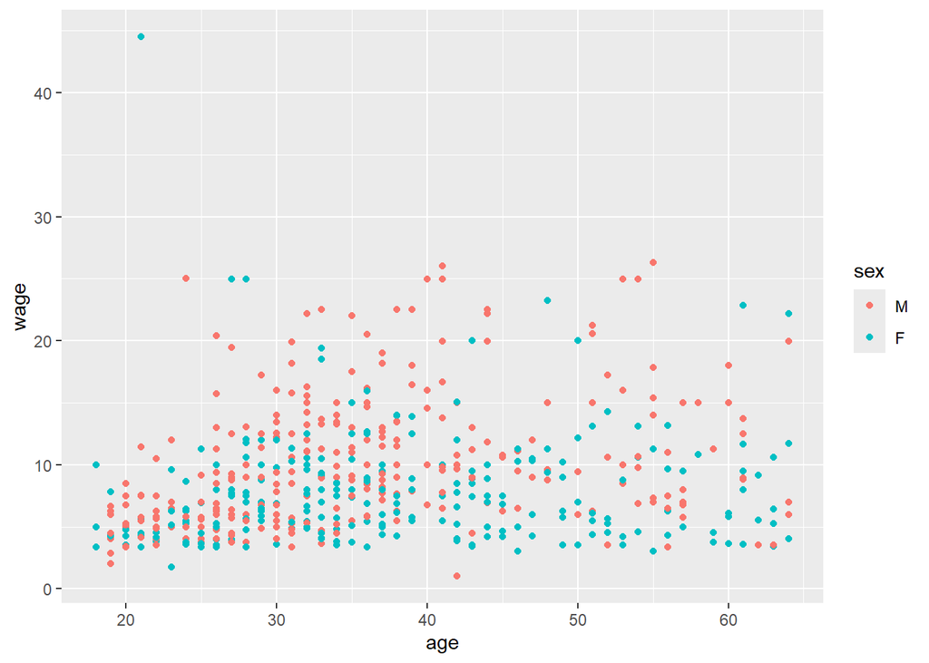

```r
# For this plot:
ggplot(CPS85_clean, aes(x = age,y = wage, color=sex))+
  geom_point()
```

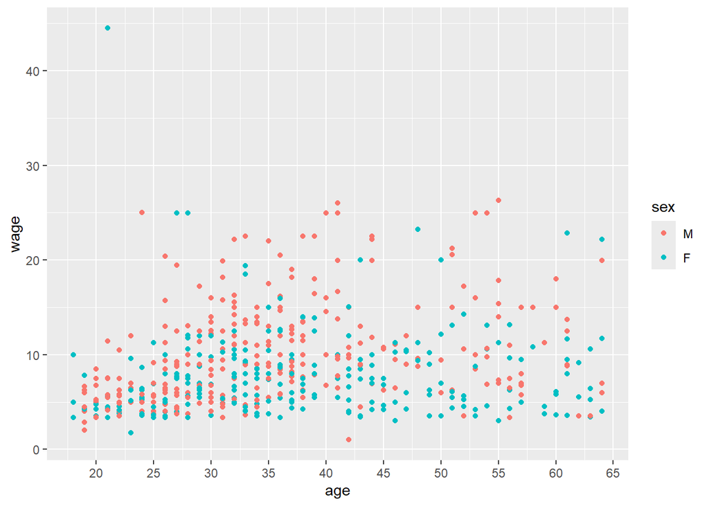

```r
# If we wanted the x-axis to show more ticks
ggplot(CPS85_clean, aes(x = age, y = wage, color = sex)) +
  geom_point() +
  scale_x_continuous(breaks = c(20,25,30,35,40,45,50,55,60,65)) # have to be within range
```

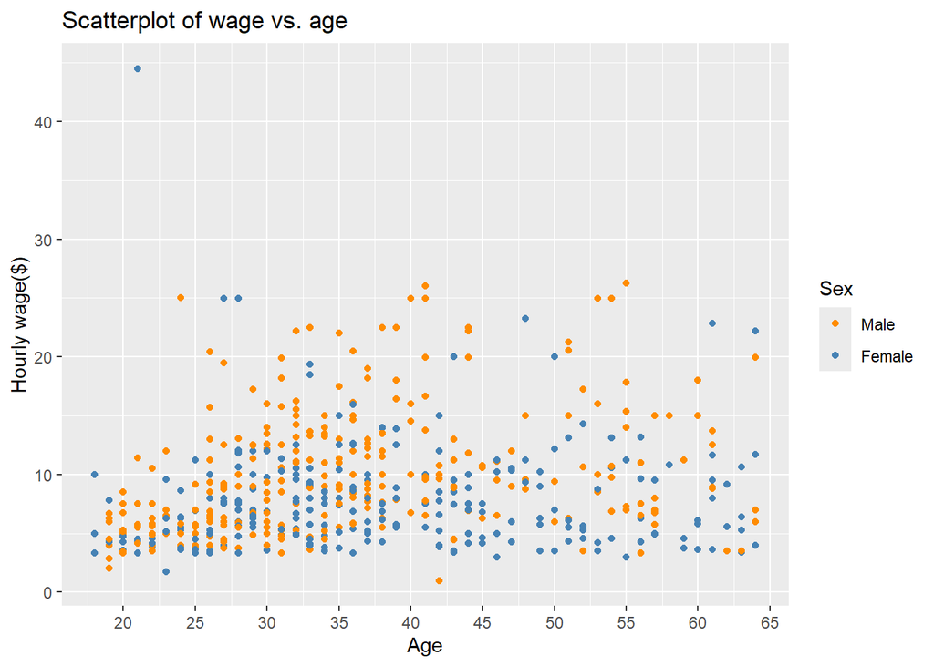

```r
# [exercise7] In the plot above, add your own title, name y-axis "hourly wage($)", and x-axis "Age", label the legends as “Male" and "Female" after assigning them colors you like

ggplot(CPS85_clean, aes(x = age, y = wage, color = sex)) +
  geom_point() +
  scale_x_continuous(breaks = c(20,25,30,35,40,45,50,55,60,65))+
  labs(title = "Scatterplot of wage vs. age",
       y = "Hourly wage($)",
       x = "Age") +
  scale_color_manual(name = "Sex",
                     labels = c("Male", "Female"),
                     values = c("darkorange", "steelblue") )
```

# Display Multiple Figures

## More cool things to explore: overlaying plots

Add a density plot on to histogram.

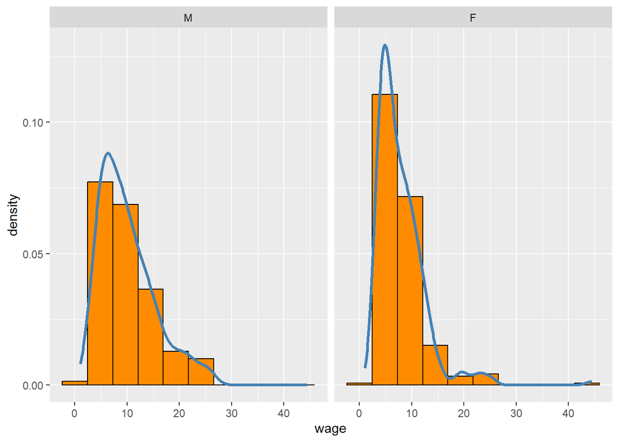

```r
# overlay a density plot on the histogram
ggplot(CPS85_clean,aes(x = wage, y = ..density..)) +
  geom_histogram(fill = "darkorange", color = "black", bins = 10) +
  geom_density(color = 'steelblue', size = 1.1) +
  facet_wrap(~sex)
```

[figure not shown]

```r
# overlay two histograms on top of each other
ggplot(CPS85_clean, aes(x = wage, fill = sex)) +
  geom_histogram(position = "identity",
                 color="white",
                  alpha = 0.5, bins = 30)+
  scale_fill_manual(values = c("steelblue", "pink"),
                    labels = c("Female", "Male"))
```

# Yes, you can customize EVERYTHING!

*ggplot* gives you the flexibility to customize almost everything. Data visualization is an art, but also it’s an important way of communication. Keep your plots clear and interpretable, and on top of that, visually pleasing if you can.

## Some more reference on R graphics and ggplot

[A good reference for customizing ggplot](https://rkabacoff.github.io/datavis/Customizing.html)

[R graphics cookbook](https://r-graphics.org/)

[The R Graph Gallery](https://r-graph-gallery.com/)

[More detailed color pallette in R](https://r-charts.com/colors/) Or google “R colors” for more options in R colors and palettes.

[A guide for finding color blind friendly colors](https://cran.r-project.org/web/packages/colorBlindness/vignettes/colorBlindness.html)